# Assignment 1

## Introduction:

My answers to Assignment 1 for B9DA100 are found below.

### Question 1:

The dataset `GSSvocab` is available in the R package called `carData`.

#### 1.1

In 1.1, we need to load the carData package and load the `GSSvocab` dataset. The commands needed to do this are:

```r
library(carData)
data(GSSvocab)
```

We also need to look at the top 6 rows of the dataset. The command needed to do this is:

```r
head(GSSvocab)
```

```
##        year gender nativeBorn ageGroup educGroup vocab age educ
## 1978.1 1978 female        yes    50-59    12 yrs    10  52   12
## 1978.2 1978 female        yes      60+   <12 yrs     6  74    9
## 1978.3 1978   male        yes    30-39   <12 yrs     4  35   10
## 1978.4 1978 female        yes    50-59    12 yrs     9  50   12
## 1978.5 1978 female        yes    40-49    12 yrs     6  41   12
## 1978.6 1978   male        yes    18-29    12 yrs     6  19   12
```

#### 1.2

In 1.2, we need to access the description and structure of the dataset. The commands needed to do this are:

```r
str(GSSvocab)
```

```
## 'data.frame':    28867 obs. of  8 variables:
##  $ year      : Factor w/ 20 levels "1978","1982",..: 1 1 1 1 1 1 1 1 1 1 ...
##  $ gender    : Factor w/ 2 levels "female","male": 1 1 2 1 1 2 2 2 1 2 ...
##  $ nativeBorn: Factor w/ 2 levels "no","yes": 2 2 2 2 2 2 2 2 2 2 ...
##  $ ageGroup  : Factor w/ 5 levels "18-29","30-39",..: 4 5 2 4 3 1 1 4 3 1 ...
##  $ educGroup : Factor w/ 5 levels "<12 yrs","12 yrs",..: 2 1 1 2 2 2 2 2 4 2 ...
##  $ vocab     : num  10 6 4 9 6 6 4 7 8 3 ...
##  $ age       : num  52 74 35 50 41 19 19 59 49 21 ...
##  $ educ      : num  12 9 10 12 12 12 12 12 16 12 ...
```

```r
?GSSvocab
```

From these commands, we can see that the data comes from a social survey study from the University of Chicago. There are 28,867 observations of 8 variables. It is a multifactor observational study, conataining the subject’s score on a vocabulary test, and factors for age group, education level, natality status, gender and year of the survey.

#### 1.3

We need to print the 2,000th row here, and also to find the age of the person in this row. There are a few ways to do this, some of which are below:

```r
GSSvocab[2000, ]
```

```
##          year gender nativeBorn ageGroup educGroup vocab age educ
## 1982.468 1982 female        yes      60+    12 yrs     3  66   12
```

```r
GSSvocab[2000, 'age']
```

```
## [1] 66
```

```r
GSSvocab[2000, 7]
```

```
## [1] 66
```

```r
GSSvocab$age[2000]
```

```
## [1] 66
```

We can see that the person in this row is 66 years old.

#### 1.4

Since each person got 0, 1, 2, … or 10 words correct, to convert this to a percentage, this column can simply be multiplied by 10:

```r
GSSvocab$vocab.pct <- GSSvocab$vocab * 10
head(GSSvocab)
```

```
##        year gender nativeBorn ageGroup educGroup vocab age educ vocab.pct
## 1978.1 1978 female        yes    50-59    12 yrs    10  52   12       100
## 1978.2 1978 female        yes      60+   <12 yrs     6  74    9        60
## 1978.3 1978   male        yes    30-39   <12 yrs     4  35   10        40
## 1978.4 1978 female        yes    50-59    12 yrs     9  50   12        90
## 1978.5 1978 female        yes    40-49    12 yrs     6  41   12        60
## 1978.6 1978   male        yes    18-29    12 yrs     6  19   12        60
```

#### 1.5

Both `ageGroup` and `educGroup` are ordinal variables, and should therefore be ordered factors in R, rather than just factors. This is easy to fix, since the levels are already in the correct ordrer:

```r
GSSvocab$ageGroup <- factor(GSSvocab$ageGroup, ordered = TRUE)
GSSvocab$educGroup <- factor(GSSvocab$educGroup, ordered = TRUE)
```

Checking the structure again to confirm that this has worked:

```r
str(GSSvocab)
```

```
## 'data.frame':    28867 obs. of  9 variables:
##  $ year      : Factor w/ 20 levels "1978","1982",..: 1 1 1 1 1 1 1 1 1 1 ...
##  $ gender    : Factor w/ 2 levels "female","male": 1 1 2 1 1 2 2 2 1 2 ...
##  $ nativeBorn: Factor w/ 2 levels "no","yes": 2 2 2 2 2 2 2 2 2 2 ...
##  $ ageGroup  : Ord.factor w/ 5 levels "18-29"<"30-39"<..: 4 5 2 4 3 1 1 4 3 1 ...
##  $ educGroup : Ord.factor w/ 5 levels "<12 yrs"<"12 yrs"<..: 2 1 1 2 2 2 2 2 4 2 ...
##  $ vocab     : num  10 6 4 9 6 6 4 7 8 3 ...
##  $ age       : num  52 74 35 50 41 19 19 59 49 21 ...
##  $ educ      : num  12 9 10 12 12 12 12 12 16 12 ...
##  $ vocab.pct : num  100 60 40 90 60 60 40 70 80 30 ...
```

Great! They are now ordered.

#### 1.6

Creating the table:

```r
table(GSSvocab$educGroup, GSSvocab$ageGroup)
```

```
##
##             18-29 30-39 40-49 50-59  60+
##   <12 yrs    1063   812   790   881 2365
##   12 yrs     1848  1785  1528  1306 2118
##   13-15 yrs  1788  1779  1345  1002 1240
##   16 yrs      775  1024   835   576  693
##   >16 yrs     368   833   737   554  655
```

Now to find which combination has the smallest number of people (this is only one way to do this - there are others):

```r
tab1 <- table(GSSvocab$educGroup, GSSvocab$ageGroup)
ind <- which(tab1 == min(tab1), arr.ind = TRUE)
tab1[ind]
```

```
## [1] 368
```

```r
rownames(tab1)[ind[1]]
```

```
## [1] ">16 yrs"
```

```r
colnames(tab1)[ind[2]]
```

```
## [1] "18-29"
```

From this, we can see that the combination of education group >16 yrs and the age group 18-29 have the smallest number of people: this number is: 368 people.

#### 1.7

Make the basic plot first:

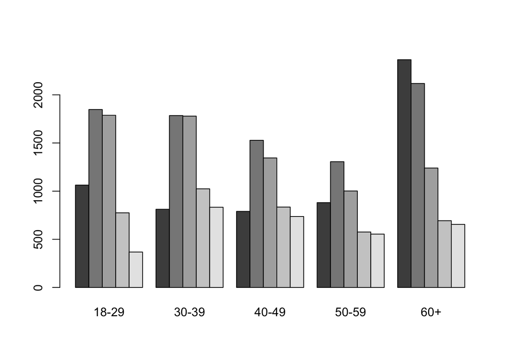

```r
barplot(tab1, beside = TRUE)
```

Now make it look neat:

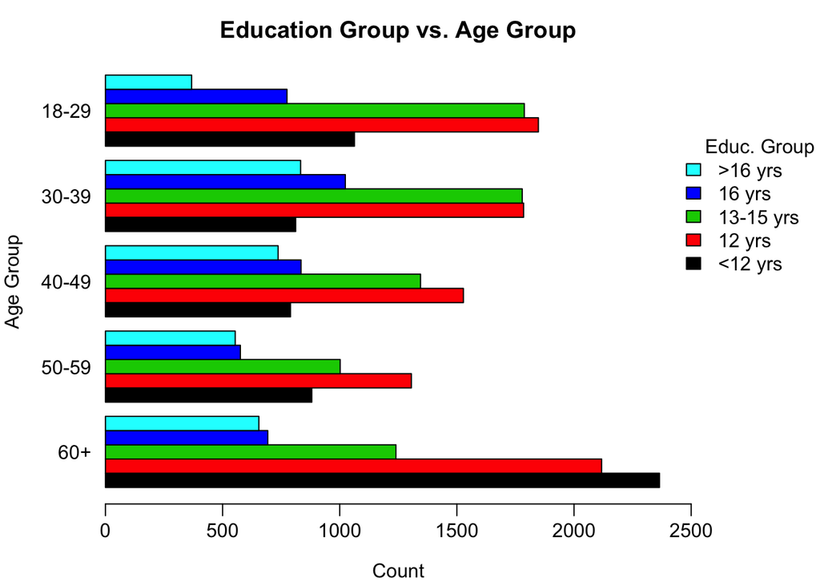

```r
par(mar = c(3.5, 4.5, 2.5, 5.5), mgp = c(3.5, 0.6, 0), las = 1)
tab1 <- tab1[ , c(ncol(tab1):1)]
barplot(tab1,
        beside = TRUE,
        legend.text = rownames(tab1),
        col = 1:5,
        horiz = TRUE,
        las = 1,
        args.legend=list(
          x=3000,
          y=25,
          bty = "n"),
        main = "Education Group vs. Age Group",
        ylab = "Age Group",
        xlim = c(0, 2500))
axis(side = 1, at = 1250, labels = "Count", pos = -3, tick = FALSE)
axis(side = 4, at = 25, labels = "Educ. Group", tick = FALSE)
```

From this, we can see that people in the 60+ category spent the least time in education with the majority spending 12 years or less there.

The majority of the time spent in education for all of the remaining age groups is either 12 years or 13-15 years.

### Question 2:

In Question 2 you need to analyse a very large dataset (>50,000 records).

The dataset `diamonds` is available in the R package called `ggplot2`.

#### 2.1

This is the code to install the package. You only need to run it once:

```r
install.packages("ggplot2")
```

Now load it, and access the dataset:

```r
library(ggplot2)
data(diamonds)
```

Looking at the structure and the top of the dataset:

```r
str(diamonds)
```

```
## Classes 'tbl_df', 'tbl' and 'data.frame':    53940 obs. of  10 variables:
##  $ carat  : num  0.23 0.21 0.23 0.29 0.31 0.24 0.24 0.26 0.22 0.23 ...
##  $ cut    : Ord.factor w/ 5 levels "Fair"<"Good"<..: 5 4 2 4 2 3 3 3 1 3 ...
##  $ color  : Ord.factor w/ 7 levels "D"<"E"<"F"<"G"<..: 2 2 2 6 7 7 6 5 2 5 ...
##  $ clarity: Ord.factor w/ 8 levels "I1"<"SI2"<"SI1"<..: 2 3 5 4 2 6 7 3 4 5 ...
##  $ depth  : num  61.5 59.8 56.9 62.4 63.3 62.8 62.3 61.9 65.1 59.4 ...
##  $ table  : num  55 61 65 58 58 57 57 55 61 61 ...
##  $ price  : int  326 326 327 334 335 336 336 337 337 338 ...
##  $ x      : num  3.95 3.89 4.05 4.2 4.34 3.94 3.95 4.07 3.87 4 ...
##  $ y      : num  3.98 3.84 4.07 4.23 4.35 3.96 3.98 4.11 3.78 4.05 ...
##  $ z      : num  2.43 2.31 2.31 2.63 2.75 2.48 2.47 2.53 2.49 2.39 ...
```

```r
head(diamonds)
```

```
## # A tibble: 6 x 10
##   carat cut       color clarity depth table price     x     y     z
##   <dbl> <ord>     <ord> <ord>   <dbl> <dbl> <int> <dbl> <dbl> <dbl>
## 1 0.23  Ideal     E     SI2      61.5    55   326  3.95  3.98  2.43
## 2 0.21  Premium   E     SI1      59.8    61   326  3.89  3.84  2.31
## 3 0.23  Good      E     VS1      56.9    65   327  4.05  4.07  2.31
## 4 0.290 Premium   I     VS2      62.4    58   334  4.2   4.23  2.63
## 5 0.31  Good      J     SI2      63.3    58   335  4.34  4.35  2.75
## 6 0.24  Very Good J     VVS2     62.8    57   336  3.94  3.96  2.48
```

You can see there are almost 54000 observations. To be more precise, There are 53940 observations and 10 variables - `carat` is numeric, `cut`, `color` and `clarity` are ordered factors (see the help file for details on the levels), while the remaining variables (`depth`, `table`, `price`, `x`, `y`, and `z`) are all numeric.

#### 2.2

Are there any missing values in the dataset? You can find this out a few ways:

```r
sum(is.na(diamonds))
```

```
## [1] 0
```

or:

```r
nrow(diamonds) == length(complete.cases(diamonds))
```

```
## [1] TRUE
```

Since every row is complete, there are no missing values in the dataset.

#### 2.3

Which row contains the diamond with a depth of 70? What colour is this diamond? We can find out the row using:

```r
which(diamonds$depth == 70)
```

```
## [1] 11779
```

And we can see this row by:

```r
diamonds[which(diamonds$depth == 70), ]
```

```
## # A tibble: 1 x 10
##   carat cut   color clarity depth table price     x     y     z
##   <dbl> <ord> <ord> <ord>   <dbl> <dbl> <int> <dbl> <dbl> <dbl>
## 1  1.83 Fair  J     I1         70    58  5083  7.34  7.28  5.12
```

And the colour of this diamond is:

```r
diamonds[which(diamonds$depth == 70), 'color']
```

```
## # A tibble: 1 x 1
##   color
##   <ord>
## 1 J
```

It’s in row 11779 and is of colour J.

#### 2.4

The `summary()` function is run by:

```r
summary(diamonds)
```

```
##      carat               cut        color        clarity
##  Min.   :0.2000   Fair     : 1610   D: 6775   SI1    :13065
##  1st Qu.:0.4000   Good     : 4906   E: 9797   VS2    :12258
##  Median :0.7000   Very Good:12082   F: 9542   SI2    : 9194
##  Mean   :0.7979   Premium  :13791   G:11292   VS1    : 8171
##  3rd Qu.:1.0400   Ideal    :21551   H: 8304   VVS2   : 5066
##  Max.   :5.0100                     I: 5422   VVS1   : 3655
##                                     J: 2808   (Other): 2531
##      depth           table           price             x
##  Min.   :43.00   Min.   :43.00   Min.   :  326   Min.   : 0.000
##  1st Qu.:61.00   1st Qu.:56.00   1st Qu.:  950   1st Qu.: 4.710
##  Median :61.80   Median :57.00   Median : 2401   Median : 5.700
##  Mean   :61.75   Mean   :57.46   Mean   : 3933   Mean   : 5.731
##  3rd Qu.:62.50   3rd Qu.:59.00   3rd Qu.: 5324   3rd Qu.: 6.540
##  Max.   :79.00   Max.   :95.00   Max.   :18823   Max.   :10.740
##
##        y                z
##  Min.   : 0.000   Min.   : 0.000
##  1st Qu.: 4.720   1st Qu.: 2.910
##  Median : 5.710   Median : 3.530
##  Mean   : 5.735   Mean   : 3.539
##  3rd Qu.: 6.540   3rd Qu.: 4.040
##  Max.   :58.900   Max.   :31.800
##
```

You should describe at least two of these results - perhaps pointing out one with an obvious skew (and saying if it’s negative or positive) or commenting on which levels of a factor are most/least common *etc.* would be a good approach.

#### 2.5

The table of `color` against `cut` is created by:

```r
table(diamonds$color, diamonds$cut)
```

```
##
##     Fair Good Very Good Premium Ideal
##   D  163  662      1513    1603  2834
##   E  224  933      2400    2337  3903
##   F  312  909      2164    2331  3826
##   G  314  871      2299    2924  4884
##   H  303  702      1824    2360  3115
##   I  175  522      1204    1428  2093
##   J  119  307       678     808   896
```

You need to use code to find the colour/cut combination with the least number of diamonds (not just read it from the output).

As before, there are different ways to do this. One way to do this is:

```r
# Create and save the table:
tab2 <- table(diamonds$color, diamonds$cut)
# Convert it to a dataframe:
df2 <- data.frame(tab2)
# Name the columns (this is just for neatness)
names(df2) <- c('color', 'cut', 'count')
# Pick out the row with the minimum count:
df2[which.min(df2$count), ]
```

```
##   color  cut count
## 7     J Fair   119
```

The `color` is J and the `cut` category is Fair. The number of diamonds with this combination is 119.

#### 2.6

Now using the table from the previous question, you need to produce a table showing proportions (instead of counts) and marginal sums. Print this new table, and comment on it.

```r
tab3 <- round(tab2 / sum(tab2), 3)
tab3
```

```
##
##      Fair  Good Very Good Premium Ideal
##   D 0.003 0.012     0.028   0.030 0.053
##   E 0.004 0.017     0.044   0.043 0.072
##   F 0.006 0.017     0.040   0.043 0.071
##   G 0.006 0.016     0.043   0.054 0.091
##   H 0.006 0.013     0.034   0.044 0.058
##   I 0.003 0.010     0.022   0.026 0.039
##   J 0.002 0.006     0.013   0.015 0.017
```

```r
addmargins(tab3)
```

```
##
##        Fair  Good Very Good Premium Ideal   Sum
##   D   0.003 0.012     0.028   0.030 0.053 0.126
##   E   0.004 0.017     0.044   0.043 0.072 0.180
##   F   0.006 0.017     0.040   0.043 0.071 0.177
##   G   0.006 0.016     0.043   0.054 0.091 0.210
##   H   0.006 0.013     0.034   0.044 0.058 0.155
##   I   0.003 0.010     0.022   0.026 0.039 0.100
##   J   0.002 0.006     0.013   0.015 0.017 0.053
##   Sum 0.030 0.091     0.224   0.255 0.401 1.001
```

This is a helpful table to have, in order to report proportions (or percentages if you multiply by 100). I have rounded to make it neater, which means that the marginal sums don’t exactly add up to 1 now, but that’s fine).

I know some of you may have done this as two separate parts, and produced the following:

```r
addmargins(tab2)
```

```
##
##        Fair  Good Very Good Premium Ideal   Sum
##   D     163   662      1513    1603  2834  6775
##   E     224   933      2400    2337  3903  9797
##   F     312   909      2164    2331  3826  9542
##   G     314   871      2299    2924  4884 11292
##   H     303   702      1824    2360  3115  8304
##   I     175   522      1204    1428  2093  5422
##   J     119   307       678     808   896  2808
##   Sum  1610  4906     12082   13791 21551 53940
```

This is fine if you did. Either way, you must comment on the findings.

There are relatively few fair diamonds, of any colour. In general, colours E, F, G and H seem more common than the other colours.

#### 2.7

According to this dataset, what is the size (length, width and depth in mm) of the most expensive diamond?

This can be found by:

```r
diamonds[which.max(diamonds$price), c('x', 'y', 'z')]
```

```
## # A tibble: 1 x 3
##       x     y     z
##   <dbl> <dbl> <dbl>
## 1   8.5  8.47  5.16
```

This gives the size (length, width and depth in mm) of the most expensive diamond.

#### 2.8

Which are the 7 most expensive prices for diamonds of clarity IF?

You need to subset the dataset to keep only those diamonds of clarity `IF`, and then order the resulting dataframe by price:

```r
sub1 <- subset(diamonds, clarity == "IF")
ind <- order(-sub1$price)
sub2 <- sub1[ind, ]
head(sub2, n = 7)
```

```
## # A tibble: 7 x 10
##   carat cut       color clarity depth table price     x     y     z
##   <dbl> <ord>     <ord> <ord>   <dbl> <dbl> <int> <dbl> <dbl> <dbl>
## 1  1.51 Ideal     G     IF       61.7    55 18806  7.37  7.41  4.56
## 2  1.28 Ideal     E     IF       60.7    57 18700  7.09  6.99  4.27
## 3  2.29 Premium   J     IF       61.4    60 18594  8.49  8.45  5.2
## 4  1.5  Very Good F     IF       63.2    58 18552  7.2   7.32  4.59
## 5  1.04 Very Good D     IF       61.3    56 18542  6.53  6.55  4.01
## 6  1.33 Ideal     F     IF       60.2    57 18435  7.12  7.17  4.3
## 7  2.29 Premium   J     IF       61.4    60 18426  8.45  8.49  5.2
```

```r
sub2$price[1:7]
```

```
## [1] 18806 18700 18594 18552 18542 18435 18426
```

The 7 most expensive diamonds of clarity `IF` cost: 18806, 18700, 18594, 18552, 18542, 18435, 18426.

#### 2.9

How many diamonds are of Ideal cut, best colour and best clarity?

Using the help file, the best colour is D, and the best clarity is IF. Therefore there are:

```r
nrow(subset(diamonds, cut == "Ideal" & color == "D" & clarity == "IF"))
```

```
## [1] 28
```

diamonds of the Ideal cut, best colour, and best clarity.

#### 2.10

Create a new column called `price.per.carat` which contains the price of a diamond divided by its carat:

```r
diamonds$price.per.carat <- diamonds$price / diamonds$carat
```

#### 2.11

Create a subset of diamonds called sub.diamonds which contains only those diamonds of cut Ideal. How many observations are there in sub.diamonds?

```r
sub.diamonds <- subset(diamonds, cut == "Ideal")
nrow(sub.diamonds)
```

```
## [1] 21551
```

There are 21551 rows in `sub.diamonds`.

#### 2.12

Use the aggregate() function to aggregate the `price.per.carat` column of `sub.diamonds` to find the mean of this variable for every `clarity` and `color` combination. Save this output as a dataframe called `df1`:

```r
df1 <- aggregate(x = sub.diamonds$price.per.carat,
                 by = list(sub.diamonds$clarity, sub.diamonds$color),
                 FUN = mean)
colnames(df1) <- c('Clarity', 'Colour', 'Price.per.Carat')
```

#### 2.13

Ordering this by the `price.per.carat` variable, descending:

```r
df1[order(-df1$Price.per.Carat), ]
```

```
##    Clarity Colour Price.per.Carat
## 8       IF      D        9034.177
## 6     VVS2      D        5023.537
## 16      IF      E        4975.468
## 7     VVS1      D        4860.549
## 30    VVS2      G        4530.858
## 22    VVS2      F        4511.928
## 42     SI2      I        4508.587
## 29     VS1      G        4487.384
## 28     VS2      G        4372.454
## 21     VS1      F        4324.246
## 34     SI2      H        4249.712
## 23    VVS1      F        4182.076
## 50     SI2      J        4147.780
## 35     SI1      H        4134.589
```

[output cut: 42 more lines]

From this, we can see that the highest mean price is for diamonds of the best colour and the best clarity, which is not surprising.

What is somewhat surprising though, is that the best clarity (IF) has some of the lowest mean prices, but these have the worst colours (I and J). So colour seems to be more important (in general) than clarity. Generally speaking, the best colours (D and E) are mostly at the top of the dataframe (most expensive) and the worst colours (I and J) are mostly at the bottom. This isn’t true in every case though.

#### 2.14

This is up to you. But you must describe your findings, not just produce a table/plot etc.

If producing plots (and this wasn’t necessary, but a possible option), note the following guidelines on what plots ‘make sense’:

| Numeric | Factor (Categorical) | Possible plot(s) |
| --- | --- | --- |
| 1 | 0 | Boxplot, histogram, density… |
| 2 | 0 | Scatterplot |
| 3+ | 0 | Pairs plot (multiple scatterplots) |
| 0 | 1 | Barplot (a.k.a. bar chart) |
| 0 | 2 | Stacked or clustered barplot |
| 1 | 1 | Boxplot by group (levels) |
| 2 | 1 | Scatterplot with colours for the groups |
| 3+ | 1 | Pairs plot (multiple scatterplots) with colours for the groups |
| 2 | 2 | Scatterplot with a combination of different colours and shapes for both factors |